# DATA MINIPULATION WITH DPLYR: SELECTING AND TRANSFORMING DATA

Load `dplyr` package:

```r
library(dplyr)
```

Import the `counties` dataset in form of `.rds` file in `0_data`:

```r
counties <- readRDS("counties.rds")
```

Examine all the variables in the counties table:

```r
glimpse(counties)
```

```
## Rows: 3,138
## Columns: 40
## $ census_id          <chr> "1001", "1003", "1005", "1007", "1009", "1011", ...
## $ state              <chr> "Alabama", "Alabama", "Alabama", "Alabama", "Ala...
## $ county             <chr> "Autauga", "Baldwin", "Barbour", "Bibb", "Blount...
## $ region             <chr> "South", "South", "South", "South", "South", "So...
## $ metro              <chr> "Metro", "Metro", "Nonmetro", "Metro", "Metro", ...
## $ population         <dbl> 55221, 195121, 26932, 22604, 57710, 10678, 20354...
## $ men                <dbl> 26745, 95314, 14497, 12073, 28512, 5660, 9502, 5...
## $ women              <dbl> 28476, 99807, 12435, 10531, 29198, 5018, 10852, ...
## $ hispanic           <dbl> 2.6, 4.5, 4.6, 2.2, 8.6, 4.4, 1.2, 3.5, 0.4, 1.5...
## $ white              <dbl> 75.8, 83.1, 46.2, 74.5, 87.9, 22.2, 53.3, 73.0, ...
## $ black              <dbl> 18.5, 9.5, 46.7, 21.4, 1.5, 70.7, 43.8, 20.3, 40...
## $ native             <dbl> 0.4, 0.6, 0.2, 0.4, 0.3, 1.2, 0.1, 0.2, 0.2, 0.6...
## $ asian              <dbl> 1.0, 0.7, 0.4, 0.1, 0.1, 0.2, 0.4, 0.9, 0.8, 0.3...
```

[output cut: 27 more lines]

### 3.1 Select a range

There are many variables in the `counties` dataset, and often you only need to work with a subset of them. For example, if we are interested in knowing how people get to work, select related columns. The colon `:` is useful for getting many columns at a time.

```r
counties %>%
  select(state, county, drive:work_at_home) %>%
  arrange(drive)
```

```
## # A tibble: 3,138 x 8
##    state   county          drive carpool transit  walk other_transp work_at_home
##    <chr>   <chr>           <dbl>   <dbl>   <dbl> <dbl>        <dbl>        <dbl>
##  1 New Yo~ New York          6.1     1.9    59.2  20.7          5.4          6.8
##  2 Alaska  Northwest Arct~  16.5    10.4     0.4  46.9         21.2          4.6
##  3 Alaska  Aleutians East~  18.4     4.9     0.5  71.2          2.2          2.8
##  4 New Yo~ Kings            18.6     4.4    61.7   8.8          2.5          3.9
##  5 Alaska  North Slope Bo~  20.1    17       2.8  37.9          7.9         14.3
##  6 Alaska  Lake and Penin~  21.2     6.8     1.1  36.2         32.4          2.4
##  7 New Yo~ Bronx            22.5     4.7    59.7   8            1.8          3.3
##  8 Alaska  Nome Census Ar~  25.8    10       0.3  36.9         22.7          4.3
##  9 Alaska  Bethel Census ~  26.5    12.7     0.5  33           22.6          4.8
## 10 Alaska  Yukon-Koyukuk ~  28.7     8.1     0.2  38.1         20.1          4.9
## # ... with 3,128 more rows
```

By selecting and arranging these columns, we can find out that cities where the fewest people drive to work are a few regions in Alaska and in New York city. By focusing on this part of the data, we can see interesting insights like people in New York mostly take transit to work, while the small parts of Alaska mostly walk.

Select industry-related variables:

```r
counties %>%
  select(state, county, population, professional:production) %>%
  # Arrange service in descending order to find which counties have the highest rates of working in the service industry
  arrange(desc(service))
```

```
## # A tibble: 3,138 x 8
##    state   county population professional service office construction production
##    <chr>   <chr>       <dbl>        <dbl>   <dbl>  <dbl>        <dbl>      <dbl>
##  1 Missis~ Tunica      10477         23.9    36.6   21.5          3.5       14.5
##  2 Texas   Kinney       3577         30      36.5   11.6         20.5        1.3
##  3 Texas   Kenedy        565         24.9    34.1   20.5         20.5        0
##  4 New Yo~ Bronx     1428357         24.3    33.3   24.2          7.1       11
##  5 Texas   Brooks       7221         19.6    32.4   25.3         11.1       11.5
##  6 Colora~ Fremo~      46809         26.6    32.2   22.8         10.7        7.6
##  7 Texas   Culbe~       2296         20.1    32.2   24.2         15.7        7.8
##  8 Califo~ Del N~      27788         33.9    31.5   18.8          8.9        6.8
##  9 Minnes~ Mahno~       5496         26.8    31.5   18.7         13.1        9.9
## 10 Virgin~ Lanca~      11129         30.3    31.2   22.8          8.1        7.6
## # ... with 3,128 more rows
```

### 3.3 Select helpers

Select helpers are functions that specify criteria for choosing columns.

- `contains()` takes strings and result the columns that contain a set of certain characters.

```r
counties %>%
  select(state, county, contains("work"))
```

```
## # A tibble: 3,138 x 6
##    state   county   work_at_home private_work public_work family_work
##    <chr>   <chr>           <dbl>        <dbl>       <dbl>       <dbl>
##  1 Alabama Autauga           1.8         73.6        20.9         0
##  2 Alabama Baldwin           3.9         81.5        12.3         0.4
##  3 Alabama Barbour           1.6         71.8        20.8         0.1
##  4 Alabama Bibb              0.7         76.8        16.1         0.4
##  5 Alabama Blount            2.3         82          13.5         0.4
##  6 Alabama Bullock           2.8         79.5        15.1         0
##  7 Alabama Butler            1.7         77.4        16.2         0.2
##  8 Alabama Calhoun           2.7         74.1        20.8         0.1
##  9 Alabama Chambers          2.1         85.1        12.1         0
## 10 Alabama Cherokee          2.5         73.1        18.5         0.5
## # ... with 3,128 more rows
```

- `starts_with`: select only the columns that start with a particular prefix.

```r
counties %>%
  select(state, county, starts_with("income"))
```

```
## # A tibble: 3,138 x 6
##    state   county   income income_err income_per_cap income_per_cap_err
##    <chr>   <chr>     <dbl>      <dbl>          <dbl>              <dbl>
##  1 Alabama Autauga   51281       2391          24974               1080
##  2 Alabama Baldwin   50254       1263          27317                711
##  3 Alabama Barbour   32964       2973          16824                798
##  4 Alabama Bibb      38678       3995          18431               1618
##  5 Alabama Blount    45813       3141          20532                708
##  6 Alabama Bullock   31938       5884          17580               2055
##  7 Alabama Butler    32229       1793          18390                714
##  8 Alabama Calhoun   41703        925          21374                489
##  9 Alabama Chambers  34177       2949          21071               1366
## 10 Alabama Cherokee  36296       1710          21811               1556
## # ... with 3,128 more rows
```

- `ends_with()`: finds columns that end with a particular string.

```r
counties %>%
  select(state, county, population, ends_with("work")) %>%
# Filter just for the counties where at least 50% of the population is engaged in public work:
  filter(public_work >= 50)
```

```
## # A tibble: 7 x 6
##   state      county              population private_work public_work family_work
##   <chr>      <chr>                    <dbl>        <dbl>       <dbl>       <dbl>
## 1 Alaska     Lake and Peninsula~       1474         42.2        51.6         0.2
## 2 Alaska     Yukon-Koyukuk Cens~       5644         33.3        61.7         0
## 3 California Lassen                   32645         42.6        50.5         0.1
## 4 Hawaii     Kalawao                     85         25          64.1         0
## 5 North Dak~ Sioux                     4380         32.9        56.8         0.1
## 6 South Dak~ Todd                      9942         34.4        55           0.8
## 7 Wisconsin  Menominee                 4451         36.8        59.1         0.4
```

For more select helpers: `?select_helpers`

### 3.3 Remove variables

Remove a variable with the minus symbol `-`:

```r
counties %>%
  select(-census_id)
```

```
## # A tibble: 3,138 x 39
##    state county region metro population   men women hispanic white black native
##    <chr> <chr>  <chr>  <chr>      <dbl> <dbl> <dbl>    <dbl> <dbl> <dbl>  <dbl>
##  1 Alab~ Autau~ South  Metro      55221 26745 28476      2.6  75.8  18.5    0.4
##  2 Alab~ Baldw~ South  Metro     195121 95314 99807      4.5  83.1   9.5    0.6
##  3 Alab~ Barbo~ South  Nonm~      26932 14497 12435      4.6  46.2  46.7    0.2
##  4 Alab~ Bibb   South  Metro      22604 12073 10531      2.2  74.5  21.4    0.4
##  5 Alab~ Blount South  Metro      57710 28512 29198      8.6  87.9   1.5    0.3
##  6 Alab~ Bullo~ South  Nonm~      10678  5660  5018      4.4  22.2  70.7    1.2
##  7 Alab~ Butler South  Nonm~      20354  9502 10852      1.2  53.3  43.8    0.1
##  8 Alab~ Calho~ South  Metro     116648 56274 60374      3.5  73    20.3    0.2
##  9 Alab~ Chamb~ South  Nonm~      34079 16258 17821      0.4  57.3  40.3    0.2
## 10 Alab~ Chero~ South  Nonm~      26008 12975 13033      1.5  91.7   4.8    0.6
## # ... with 3,128 more rows, and 28 more variables: asian <dbl>, pacific <dbl>,
## #   citizens <dbl>, income <dbl>, income_err <dbl>, income_per_cap <dbl>,
## #   income_per_cap_err <dbl>, poverty <dbl>, child_poverty <dbl>,
## #   professional <dbl>, service <dbl>, office <dbl>, construction <dbl>,
## #   production <dbl>, drive <dbl>, carpool <dbl>, transit <dbl>, walk <dbl>,
## #   other_transp <dbl>, work_at_home <dbl>, mean_commute <dbl>, employed <dbl>,
## #   private_work <dbl>, public_work <dbl>, self_employed <dbl>,
## #   family_work <dbl>, unemployment <dbl>, land_area <dbl>
```

### 3.4 Rename variables

Rename the `unemployment` column to `unemployment_rate`:

```r
counties %>%
  select(state, county, unemployment) %>%
  rename(unemployment_rate = unemployment)
```

```
## # A tibble: 3,138 x 3
##    state   county   unemployment_rate
##    <chr>   <chr>                <dbl>
##  1 Alabama Autauga                7.6
##  2 Alabama Baldwin                7.5
##  3 Alabama Barbour               17.6
##  4 Alabama Bibb                   8.3
##  5 Alabama Blount                 7.7
##  6 Alabama Bullock               18
##  7 Alabama Butler                10.9
##  8 Alabama Calhoun               12.3
##  9 Alabama Chambers               8.9
## 10 Alabama Cherokee               7.9
## # ... with 3,128 more rows
```

Or use `select()` with rename argument:

```r
counties %>%
  select(state, county, unemployment_rate = unemployment)
```

```
## # A tibble: 3,138 x 3
##    state   county   unemployment_rate
##    <chr>   <chr>                <dbl>
##  1 Alabama Autauga                7.6
##  2 Alabama Baldwin                7.5
##  3 Alabama Barbour               17.6
##  4 Alabama Bibb                   8.3
##  5 Alabama Blount                 7.7
##  6 Alabama Bullock               18
##  7 Alabama Butler                10.9
##  8 Alabama Calhoun               12.3
##  9 Alabama Chambers               8.9
## 10 Alabama Cherokee               7.9
## # ... with 3,128 more rows
```

The `rename` verb is often useful for changing the name of a column that comes out of another verb, such as `count()`.

```r
counties %>%
  count(state) %>%
  rename(num_counties = n)
```

```
## # A tibble: 50 x 2
##    state       num_counties
##    <chr>              <int>
##  1 Alabama               67
##  2 Alaska                28
##  3 Arizona               15
##  4 Arkansas              75
##  5 California            58
##  6 Colorado              64
##  7 Connecticut            8
##  8 Delaware               3
##  9 Florida               67
## 10 Georgia              159
## # ... with 40 more rows
```

### 3.4 transmute()

`transmute()` is a combination of `select()` and `mutate()` to get a subset of the columns and transform and change them at the same time. For example, select and calculate a fraction of the population that made up of men:

```r
counties %>%
  transmute(state, county, fraction_men = men/population)
```

```
## # A tibble: 3,138 x 3
##    state   county   fraction_men
##    <chr>   <chr>           <dbl>
##  1 Alabama Autauga         0.484
##  2 Alabama Baldwin         0.488
##  3 Alabama Barbour         0.538
##  4 Alabama Bibb            0.534
##  5 Alabama Blount          0.494
##  6 Alabama Bullock         0.530
##  7 Alabama Butler          0.467
##  8 Alabama Calhoun         0.482
##  9 Alabama Chambers        0.477
## 10 Alabama Cherokee        0.499
## # ... with 3,128 more rows
```

This saves some effort comparing to using both `mutate()` and `select()`.

Use `transmute()` to control which variables to keep, which variables to calculate, and which variables to drop:

```r
counties %>%
  transmute(state, county, population, density = population/land_area) %>%
  filter(population > 1000000) %>%
  arrange(density)
```

```
## # A tibble: 41 x 4
##    state      county         population density
##    <chr>      <chr>               <dbl>   <dbl>
##  1 California San Bernardino    2094769    104.
##  2 Nevada     Clark             2035572    258.
##  3 California Riverside         2298032    319.
##  4 Arizona    Maricopa          4018143    437.
##  5 Florida    Palm Beach        1378806    700.
##  6 California San Diego         3223096    766.
##  7 Washington King              2045756    967.
##  8 Texas      Travis            1121645   1133.
##  9 Florida    Hillsborough      1302884   1277.
## 10 Florida    Orange            1229039   1360.
## # ... with 31 more rows
```

Summary of the four verbs in `dplyr`:

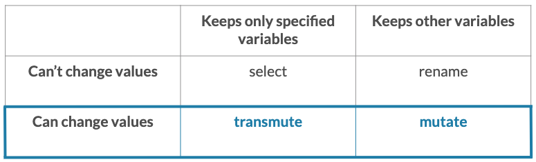

```r
counties %>% # change the name a column.
  rename(unemployment_rate = unemployment)
```

```
## # A tibble: 3,138 x 40
##    census_id state county region metro population   men women hispanic white
##    <chr>     <chr> <chr>  <chr>  <chr>      <dbl> <dbl> <dbl>    <dbl> <dbl>
##  1 1001      Alab~ Autau~ South  Metro      55221 26745 28476      2.6  75.8
##  2 1003      Alab~ Baldw~ South  Metro     195121 95314 99807      4.5  83.1
##  3 1005      Alab~ Barbo~ South  Nonm~      26932 14497 12435      4.6  46.2
##  4 1007      Alab~ Bibb   South  Metro      22604 12073 10531      2.2  74.5
##  5 1009      Alab~ Blount South  Metro      57710 28512 29198      8.6  87.9
##  6 1011      Alab~ Bullo~ South  Nonm~      10678  5660  5018      4.4  22.2
##  7 1013      Alab~ Butler South  Nonm~      20354  9502 10852      1.2  53.3
##  8 1015      Alab~ Calho~ South  Metro     116648 56274 60374      3.5  73
##  9 1017      Alab~ Chamb~ South  Nonm~      34079 16258 17821      0.4  57.3
## 10 1019      Alab~ Chero~ South  Nonm~      26008 12975 13033      1.5  91.7
## # ... with 3,128 more rows, and 30 more variables: black <dbl>, native <dbl>,
## #   asian <dbl>, pacific <dbl>, citizens <dbl>, income <dbl>, income_err <dbl>,
## #   income_per_cap <dbl>, income_per_cap_err <dbl>, poverty <dbl>,
## #   child_poverty <dbl>, professional <dbl>, service <dbl>, office <dbl>,
## #   construction <dbl>, production <dbl>, drive <dbl>, carpool <dbl>,
## #   transit <dbl>, walk <dbl>, other_transp <dbl>, work_at_home <dbl>,
## #   mean_commute <dbl>, employed <dbl>, private_work <dbl>, public_work <dbl>,
## #   self_employed <dbl>, family_work <dbl>, unemployment_rate <dbl>,
## #   land_area <dbl>
```

```r
counties %>% # select and keep columns.
  select(state, county, contains("poverty"))
```

```
## # A tibble: 3,138 x 4
##    state   county   poverty child_poverty
##    <chr>   <chr>      <dbl>         <dbl>
##  1 Alabama Autauga     12.9          18.6
##  2 Alabama Baldwin     13.4          19.2
##  3 Alabama Barbour     26.7          45.3
##  4 Alabama Bibb        16.8          27.9
##  5 Alabama Blount      16.7          27.2
##  6 Alabama Bullock     24.6          38.4
##  7 Alabama Butler      25.4          39.2
##  8 Alabama Calhoun     20.5          31.6
##  9 Alabama Chambers    21.6          37.2
## 10 Alabama Cherokee    19.2          30.1
## # ... with 3,128 more rows
```

```r
counties %>% # calculate a column without dropping the other columns.
  mutate(fraction_women = women / population)
```

```
## # A tibble: 3,138 x 41
##    census_id state county region metro population   men women hispanic white
##    <chr>     <chr> <chr>  <chr>  <chr>      <dbl> <dbl> <dbl>    <dbl> <dbl>
##  1 1001      Alab~ Autau~ South  Metro      55221 26745 28476      2.6  75.8
##  2 1003      Alab~ Baldw~ South  Metro     195121 95314 99807      4.5  83.1
##  3 1005      Alab~ Barbo~ South  Nonm~      26932 14497 12435      4.6  46.2
##  4 1007      Alab~ Bibb   South  Metro      22604 12073 10531      2.2  74.5
##  5 1009      Alab~ Blount South  Metro      57710 28512 29198      8.6  87.9
##  6 1011      Alab~ Bullo~ South  Nonm~      10678  5660  5018      4.4  22.2
##  7 1013      Alab~ Butler South  Nonm~      20354  9502 10852      1.2  53.3
##  8 1015      Alab~ Calho~ South  Metro     116648 56274 60374      3.5  73
##  9 1017      Alab~ Chamb~ South  Nonm~      34079 16258 17821      0.4  57.3
## 10 1019      Alab~ Chero~ South  Nonm~      26008 12975 13033      1.5  91.7
## # ... with 3,128 more rows, and 31 more variables: black <dbl>, native <dbl>,
## #   asian <dbl>, pacific <dbl>, citizens <dbl>, income <dbl>, income_err <dbl>,
## #   income_per_cap <dbl>, income_per_cap_err <dbl>, poverty <dbl>,
## #   child_poverty <dbl>, professional <dbl>, service <dbl>, office <dbl>,
## #   construction <dbl>, production <dbl>, drive <dbl>, carpool <dbl>,
## #   transit <dbl>, walk <dbl>, other_transp <dbl>, work_at_home <dbl>,
## #   mean_commute <dbl>, employed <dbl>, private_work <dbl>, public_work <dbl>,
## #   self_employed <dbl>, family_work <dbl>, unemployment <dbl>,
## #   land_area <dbl>, fraction_women <dbl>
```

```r
counties %>% # select and calculate columns.
  transmute(state, county, employment_rate = employed / population)
```

```
## # A tibble: 3,138 x 3
##    state   county   employment_rate
##    <chr>   <chr>              <dbl>
##  1 Alabama Autauga            0.434
##  2 Alabama Baldwin            0.441
##  3 Alabama Barbour            0.319
##  4 Alabama Bibb               0.367
##  5 Alabama Blount             0.384
##  6 Alabama Bullock            0.362
##  7 Alabama Butler             0.384
##  8 Alabama Calhoun            0.406
##  9 Alabama Chambers           0.402
## 10 Alabama Cherokee           0.390
## # ... with 3,128 more rows
```